# Part II - Loan Data from Prosper

## by Adeleke Babatunde

## Investigation Overview

> The overall goal of the presentation is to highlights factors that affect loan status especially defaulted loans. Below is the summary of key insights

## Dataset Overview

> The dataset used in this analysis is the Loan data by Prosper. The data is provided as a csv file with 113,937 loans with 81 variables on each loan. The data is loaded using the URL provided in the project workspace resource for linked files which an amazon s3 storage URL. The Data has so many features but since this analysis is focused on factors that affect the loan status, the following data wrangling steps were performed
> 1. Data without a prosper rating were removed
> 2. Removal of unneeded columns
> 3. Datatype of LoanOriginationDate was changed from object to date
> 4. ProsperRating (Alpha) and listingCategory (numeric) were renamed to ProsperRating and listingCategory respectively
> 5. Encoding of listingCategory with information in the data dictionary
> 6. Creation of a new column to hold the Loan Origination Year from LoanOriginationDate to allow analysis by year of Loan Origination

> The Wrangling steps listed above reduced the dataset to 84,853 loans and 14 features

## Loan Status by Loan Amount and Listing Category

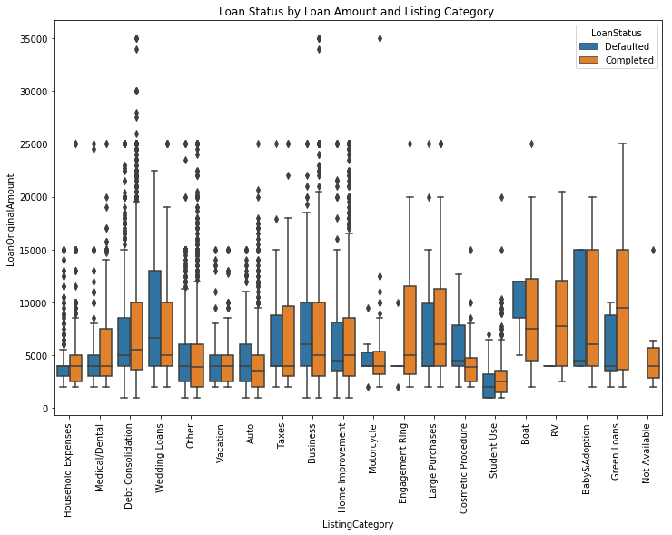

## Loan Status by Employment Status

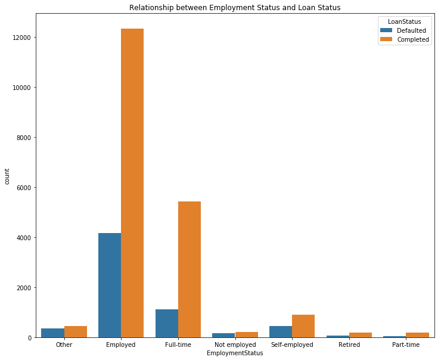

## Loan Status by Their Prosper Rating

> We can see that majority of the loans that defaulted are from the Prosper Rating HR, D and E

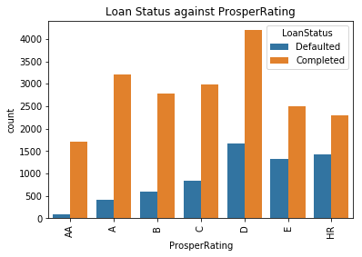

## Loan Status by Income Range and Loan Amount

> We can observe the impact of the income range on defaults as well as on the Loan amount taken

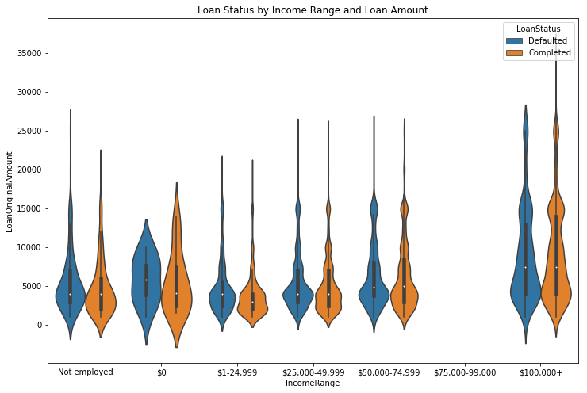